# Title :- Finding Resistance with Linear Regression

## Theory

Resistors play a crucial role in electronics and circuits for their use in controlling electrical current. They are simply a small device that limits the flow of current throughout a circuit, or in other words, impedes the flow of current through resistance. Hence, the term resistor comes to mind when describing this type of electronic device.

A resistor takes advantage of the fact that it follows what we call Ohm's Law where a resistor placed under a potential V is proportional to current I and overall resistivity value of a resistor. To be more exact, Ohm's law writes $$V = I*R$$

Now, suppose that we have an unknown resistor. To determine the value of a resistor we must rst provide a voltage across it along with a known value of current. The equipment that we use would include a power supply source that does this for us. Once a power output is provided, we can measure the resistor by determining the value of current with a given voltage output. After measuring values for voltage output and current, we should expect a linear model as an expectation for understanding the value of a resistor. $$Ohms = \frac{Volts}{Amperes}$$
$$ 1 Ohm= \frac{1 Volts} {1 Ampere }$$

[figure not shown]

Figure 1: The color bars on this resistor denote the total value of the resis- tor itself. This is common among all resistors that provides information when building a circuit.

[figure not shown]

Figure 2: A set of resistors laid out showing difierent representations of resis- tance values. The bands represent multipliers and digits of Ohmic value.

## Procudre

So, let’s imagine such a school experiment: you have a circuit with a battery providing voltage, and a load (resistor). Imagine also that the teacher does not say the resistance value of the resistor, and our task is to calculate it by ourselves. Fortunately, we have several batteries with different voltage, and we have an ammeter that measures the current. We will alternately connect these batteries to the circuit and record the values of the voltage and the current. We will get a series of numbers:

$V_1,I_1,V_2,I_2,......V_n,I_n$

Then we plot them on the plane of coordinates: the current on the x axis and the voltage on the y axis, and without almost any surprise we find out that they line up in an almost ideal straight line. Why do we say “almost”? As you know, there is an inevitable error in any experiments. It can be caused by the measurement error or by the fact that the copper wires, which we use, also have their own resistance. Do not forget that physical equations are only ideal models of the real world

## Analysis

#### Downloading the Data

The dataset contains 51 rows and 2 columns. Each column of the dataset contains information about current and voltage.

For this lab we will writing a Python script that models the value of a resistor given a set of data values performed on a laboratory environment. The datavalues provided however come with some noise with in the data that can obscure the actual value of the resistor. To x this problem we must employ the use of statistics to determine an approximate value for our resistor of interest. In statistics, the use of Linear Regression gives us the line of best fit in addition to finding our margin of error given a set of data. This type of analysis allows us to not only predict corresponding values for prediction, but also gives us a close approximation for the value of a resistor, R. Furthermore, the use of linear regression starts by understanding the line of best fit, $$y = a + bx$$

where just like a linear function, has an intercept a and slope b associated.Specific to our problem now, is that resistance can be modeled with a linear function

$$ V = a + RI$$

where in a laboratory setting, our independent variable of interest is the current I given as an output from a power source. In turn, the dependent variable in our expression is the output voltage as we vary the current. The slope, R, becomes our variable of interest. By approximating this value through linear regression given a data set should allow us to model any resistor given a set of data values.

The value of slope in a linear regression model can be expressed through means of statistical derivations, but the expression we are interested in is

[figure not shown]

[figure not shown]

Given the expression for slope of a linear regression, we can first assume that the resistance is given by the set of data points ($X_i$; $Y_i$),

[figure not shown]

First of all, we import the necessary NumPy,Seaborn and Matplotlib libraries in our code

```python
import numpy as np
import matplotlib.pyplot as plt
import seaborn as sns
import matplotlib
```

Next, we load the data.

```python
data = np.loadtxt("resistance_data.txt")
x  =  data [ :,0]# separate  data  into  x  values
y  =  data [ :,1 ]# separate  data  into  y  values
n  =len( x )
```

First, we calculate the sum. Of course, we could use the for loop, but this method is inefficient. It is much better to use the NumPy library, which works with arrays, and all calculations are much faster. We will use special functions of the library.

```python
denominator = x.dot(x) - x.mean() * x.sum()
```

Now you understand why it is so good to use the NumPy library. Now calculate the numerators of the coefficients a and b.

```python
a = ( x.dot(y) - y.mean()*x.sum() ) / denominator
b = ( y.mean() * x.dot(x) - x.mean() * x.dot(y) ) / denominator
```

Now calculate our predicted Yhat

```python
Yhat = a*x + b
```

Plot a graph of experiment data and predicated value

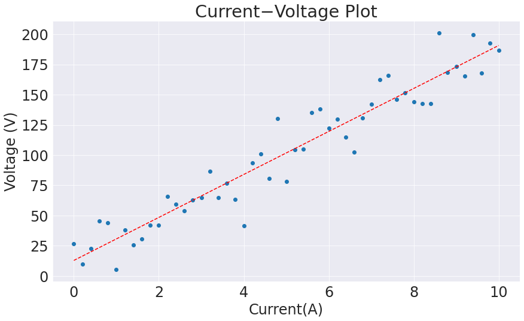

```python
matplotlib.rcParams['font.size'] = 24
sns.set_style("darkgrid")
plt.figure(figsize=(14,8) )
plt.xlabel("Current(A)")
plt.ylabel("Voltage (V)" )
plt.title ("Current−Voltage Plot")
plt.scatter(x, y)
plt.plot(x, Yhat, ls='--', c='r')
plt.show()
```

Here red line represent linear regression model and scatter plot are represent experiment value

### Determination of the error of linear regression

```python
d1 = y - Yhat
d2 = y - y.mean()
r2 = d1.dot(d1) / d2.dot(d2)
accuracy= (1-r2)*100

print("Resistance value :- ",a)
print("Error in our linear regression:- ",r2*100," %")
print("Accurity of linear regression:- ",accuracy ,"%")
```

```
Resistance value :-  17.78820950226244
Error in our linear regression:-  8.099347084357467  %
Accurity of linear regression:-  91.90065291564254 %
```

## Result

Ohm's Law deals with the relationship between voltage and current in an ideal conductor. This relationship states that: The potential difference (voltage) across an ideal conductor is proportional to the current through it. The constant of proportionality is called the "resistance", R. This can be expressed in an equation as V=IR and can be manipulated to find the other two variables. (I and R) The point of graphing this lab experiment was to establish the relationship between current and voltage. Ohm's law can be verified experimentally and we can use it to measure the value of unknown resistance , and verify the series and parallel combination of resistors experimentally

Our linear regression model is 91.90% accuracy and 8.09 % error

Resistance value :- 17.78 Ohms